# Open Payments Data Cleaning

Peter Higgins

6/22/2022

## Test data.table for analysis

## Total pharma spend on pulmonary by year

1. Did this slow down during the Sunshine Act Era? Did Naming and Shaming Work?
2. What was the Effect of COVID?

First as a table, then as a plot.

Open Payments, Annual Pharma Spend on Pulmonary

2013-2021

| Year | Dollars |
| --- | --- |
| 2013 | 13,960,668.17 |
| 2014 | 28,663,136.51 |
| 2015 | 37,641,140.68 |
| 2016 | 34,836,931.09 |
| 2017 | 38,705,017.92 |
| 2018 | 40,551,553.97 |
| 2019 | 44,696,122.59 |
| 2020 | 21,582,523.90 |
| 2021 | 26,565,953.40 |

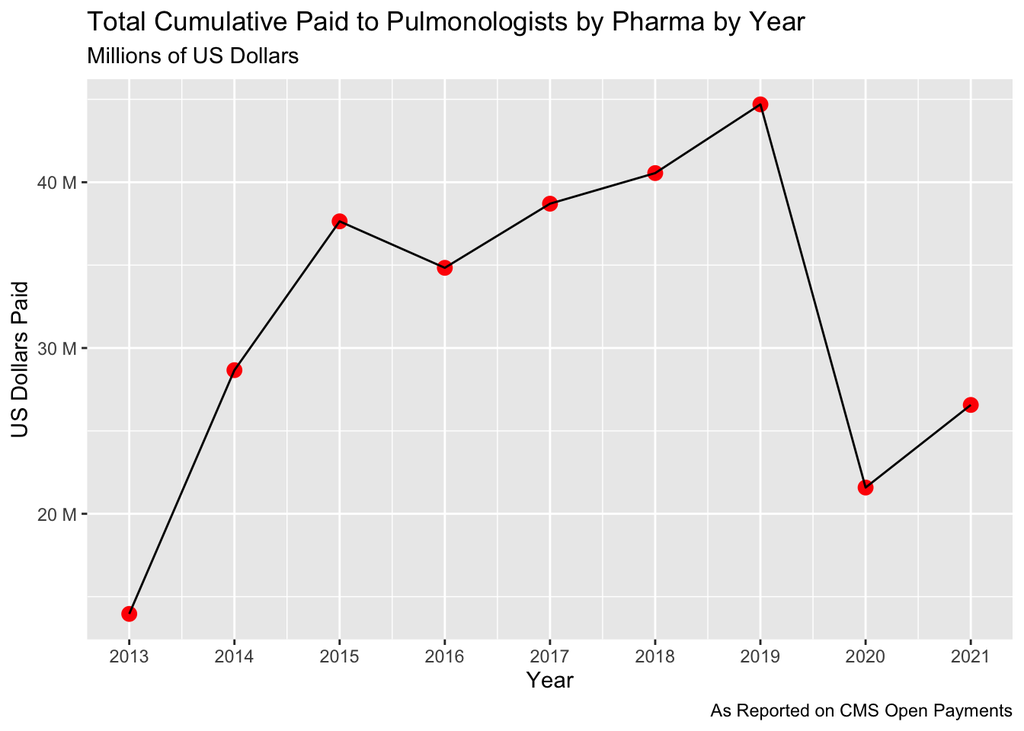

While 2013 and 2014 may represent incomplete reporting, it appears that the overall trend was steady growth despite the Sunshine Act. This changed in 2020, when COVID had a much larger effect than the Sunshine Act, reducing pharma transfers by more than 50%, with a partial rebound in 2021.

### Data.table translation help

https://atrebas.github.io/post/2019-03-03-datatable-dplyr/#read-write-data

## Total pharma spend on pulmonary by year by Category of General Spend (Nature of Payment field)

Perhaps some areas went down, like Food and Beverage, or Entertainment, in response to the Sunshine Act, even if overall spend went up.

one table, two graphs with different scales

Open Payments, Annual Pharma Spend on Pulmonary

by Category, 2013-2021

| Year | Category | Dollars |
| --- | --- | --- |
| 2013 | Charitable Contribution | 9,250.00 |
| 2014 | Charitable Contribution | 1,000.00 |
| 2016 | Charitable Contribution | 600.00 |
| 2013 | Compensation for services other than consulting, including serving as faculty or as a speaker at a venue other than a continuing education program | 8,009,272.93 |
| 2014 | Compensation for services other than consulting, including serving as faculty or as a speaker at a venue other than a continuing education program | 13,359,301.60 |
| 2015 | Compensation for services other than consulting, including serving as faculty or as a speaker at a venue other than a continuing education program | 15,630,698.57 |
| 2016 | Compensation for services other than consulting, including serving as faculty or as a speaker at a venue other than a continuing education program | 11,691,274.69 |
| 2017 | Compensation for services other than consulting, including serving as faculty or as a speaker at a venue other than a continuing education program | 16,264,787.98 |
| 2018 | Compensation for services other than consulting, including serving as faculty or as a speaker at a venue other than a continuing education program | 15,284,952.15 |
| 2019 | Compensation for services other than consulting, including serving as faculty or as a speaker at a venue other than a continuing education program | 19,799,350.87 |
| 2020 | Compensation for services other than consulting, including serving as faculty or as a speaker at a venue other than a continuing education program | 10,970,043.36 |
| 2021 | Compensation for services other than consulting, including serving as faculty or as a speaker at a venue other than a continuing education program | 14,357,910.26 |
| 2021 | Compensation for serving as faculty or as a speaker for a medical education program | 51,099.00 |
| 2013 | Compensation for serving as faculty or as a speaker for a non-accredited and noncertified continuing education program | 270,700.00 |
| 2014 | Compensation for serving as faculty or as a speaker for a non-accredited and noncertified continuing education program | 211,792.59 |
| 2015 | Compensation for serving as faculty or as a speaker for a non-accredited and noncertified continuing education program | 144,631.42 |
| 2016 | Compensation for serving as faculty or as a speaker for a non-accredited and noncertified continuing education program | 154,855.81 |
| 2017 | Compensation for serving as faculty or as a speaker for a non-accredited and noncertified continuing education program | 13,019.00 |
| 2018 | Compensation for serving as faculty or as a speaker for a non-accredited and noncertified continuing education program | 40,828.75 |
| 2019 | Compensation for serving as faculty or as a speaker for a non-accredited and noncertified continuing education program | 103,392.50 |
| 2020 | Compensation for serving as faculty or as a speaker for a non-accredited and noncertified continuing education program | 14,025.00 |
| 2013 | Compensation for serving as faculty or as a speaker for an accredited or certified continuing education program | 1,000.00 |
| 2014 | Compensation for serving as faculty or as a speaker for an accredited or certified continuing education program | 19,696.90 |
| 2015 | Compensation for serving as faculty or as a speaker for an accredited or certified continuing education program | 7,253.25 |
| 2016 | Compensation for serving as faculty or as a speaker for an accredited or certified continuing education program | 19,561.20 |
| 2017 | Compensation for serving as faculty or as a speaker for an accredited or certified continuing education program | 46,150.00 |
| 2018 | Compensation for serving as faculty or as a speaker for an accredited or certified continuing education program | 20,150.00 |
| 2019 | Compensation for serving as faculty or as a speaker for an accredited or certified continuing education program | 3,390.00 |
| 2013 | Consulting Fee | 1,830,541.19 |
| 2014 | Consulting Fee | 5,080,017.52 |

[output cut: 86 more lines]

### Now a plot of the big money

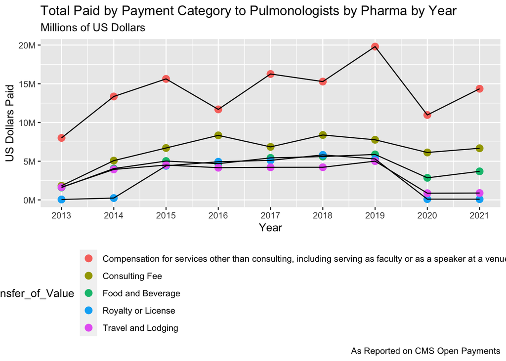

### Now a plot of the small money

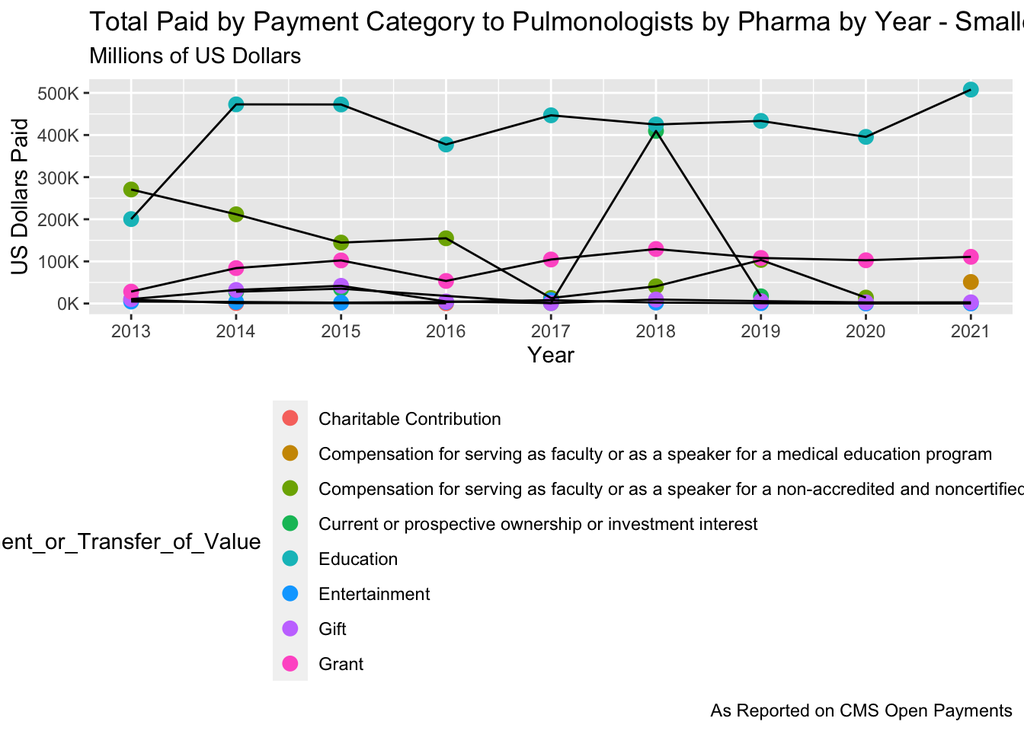

## Which Companies are spending the most, and on which products?

Top Drug Spend by Drug, Overall

Open Payments, Total Pharma Spend on Pulmonary

by Product, 2013-2021

| Product | Dollars |
| --- | --- |
| BD Nexiva | 15,205,147.00 |
| TRELEGY ELLIPTA | 12,324,114.60 |
| SYMBICORT | 10,335,716.61 |
| OFEV | 10,059,907.70 |
| Esbriet | 7,426,674.07 |
| FASENRA | 6,514,954.16 |
| Adempas | 5,445,990.65 |
| BEVESPI AEROSPHERE | 5,130,971.09 |
| OPSUMIT MACITENTAN | 5,105,773.64 |
| ACTHAR | 4,948,828.28 |
| TUDORZA | 4,868,918.33 |
| Prolastin-C | 4,549,605.24 |
| BREO | 4,120,372.22 |
| ANORO | 4,063,254.07 |
| NUCALA | 4,027,999.02 |
| SPIRIVA | 3,772,194.37 |
| ELIQUIS | 3,673,894.98 |
| DUPIXENT | 3,513,190.12 |
| BD NEXIVA | 3,320,769.00 |
| BREZTRI | 3,160,312.43 |
| STIOLTO RESPIMAT | 3,141,621.80 |
| UTIBRON | 3,140,047.10 |
| LONHALA MAGNAIR | 3,062,210.14 |
| Yupelri | 3,023,586.63 |
| UPTRAVI | 2,473,554.66 |
| Spin | 2,471,902.64 |
| ORENITRAM | 2,404,752.90 |
| Xolair | 2,239,833.57 |
| ANORO ELLIPTA | 2,176,476.36 |
| STIOLTO | 1,937,126.81 |
| XARELTO | 1,787,402.76 |
| Da Vinci Surgical System | 1,759,592.07 |
| REMODULIN | 1,587,336.97 |
| Xarelto | 1,529,817.23 |
| Letairis | 1,476,708.19 |
| superDimension | 1,421,041.25 |
| Arikayce | 1,411,646.85 |
| DALIRESP | 1,407,871.76 |
| ZERBAXA | 1,164,128.80 |
| Xyrem | 1,124,777.78 |
| GLASSIA | 1,100,347.33 |
| Monarch Platform | 1,060,308.16 |

Top Table first, limited to a total of >=1M from 2013-2021

Open Payments, Total Pharma Spend on Pulmonary

by Product, 2013-2021

| PharmaCo | Product | Dollars |
| --- | --- | --- |
| Boehringer Ingelheim Pharmaceuticals, Inc. |  | 17,977,967.53 |
| Becton, Dickinson and Company | BD Nexiva | 15,205,147.00 |
| GlaxoSmithKline, LLC. | TRELEGY ELLIPTA | 12,324,114.60 |
| AstraZeneca Pharmaceuticals LP | SYMBICORT | 10,335,716.61 |
| Boehringer Ingelheim Pharmaceuticals, Inc. | OFEV | 9,062,781.84 |
| Genentech, Inc. | Esbriet | 7,426,674.07 |
| AstraZeneca Pharmaceuticals LP | FASENRA | 6,512,279.16 |
| AstraZeneca Pharmaceuticals LP |  | 6,305,495.34 |
| Becton, Dickinson and Company |  | 5,797,849.99 |
| Actelion Pharmaceuticals US, Inc. | OPSUMIT MACITENTAN | 5,105,773.64 |
| AstraZeneca Pharmaceuticals LP | BEVESPI AEROSPHERE | 5,079,020.42 |
| Forest Laboratories, Inc. | TUDORZA | 4,858,714.95 |
| Bayer HealthCare Pharmaceuticals Inc. | Adempas | 4,485,234.22 |
| Actelion Pharmaceuticals US, Inc. |  | 4,446,692.06 |
| GlaxoSmithKline, LLC. | BREO | 4,120,372.22 |
| GlaxoSmithKline, LLC. | ANORO | 4,063,254.07 |
| GlaxoSmithKline, LLC. | NUCALA | 4,027,999.02 |
| Grifols Shared Services North America, Inc. | Prolastin-C | 3,923,374.71 |
| Boehringer Ingelheim Pharmaceuticals, Inc. | SPIRIVA | 3,711,736.47 |
| GlaxoSmithKline, LLC. |  | 3,354,216.05 |
| Becton, Dickinson and Company | BD NEXIVA | 3,320,769.00 |
| AstraZeneca Pharmaceuticals LP | BREZTRI | 3,160,312.43 |
| Sunovion Pharmaceuticals Inc. | LONHALA MAGNAIR | 3,062,210.14 |
| Sunovion Pharmaceuticals Inc. | UTIBRON | 2,815,694.69 |
| Mallinckrodt LLC | ACTHAR | 2,777,092.30 |
| Boehringer Ingelheim Pharmaceuticals, Inc. | STIOLTO RESPIMAT | 2,745,568.90 |
| Genentech, Inc. |  | 2,684,179.38 |
| Veran Medical Technologies, Inc. | Spin | 2,471,902.64 |
| United Therapeutics Corporation | ORENITRAM | 2,404,752.90 |
| Genentech, Inc. | Xolair | 2,197,140.44 |
| GlaxoSmithKline, LLC. | ANORO ELLIPTA | 2,176,476.36 |
| Sanofi and Genzyme US Companies | DUPIXENT | 2,073,221.21 |
| Pfizer Inc. | ELIQUIS | 2,014,440.99 |
| Mylan Specialty L.P. | Yupelri | 1,894,362.49 |
| Janssen Pharmaceuticals, Inc | XARELTO | 1,762,538.13 |
| Intuitive Surgical, Inc. | Da Vinci Surgical System | 1,759,592.07 |
| Boehringer Ingelheim Pharmaceuticals, Inc. | STIOLTO | 1,629,744.21 |
| Gilead Sciences Inc |  | 1,588,045.44 |
| United Therapeutics Corporation | REMODULIN | 1,587,336.97 |
| Bristol-Myers Squibb Company | ELIQUIS | 1,544,738.11 |
| Boehringer Ingelheim Pharma GmbH & Co.KG |  | 1,534,473.34 |
| United Therapeutics Corporation |  | 1,534,225.87 |
| Covidien LP |  | 1,523,213.63 |
| Janssen Pharmaceuticals, Inc | Xarelto | 1,505,506.72 |
| Insmed, Inc. | Arikayce | 1,411,646.85 |
| Janssen Pharmaceuticals, Inc | UPTRAVI | 1,379,751.97 |
| Gilead Sciences Inc | Letairis | 1,363,447.83 |
| Covidien LP | superDimension | 1,355,956.82 |
| AstraZeneca Pharmaceuticals LP | DALIRESP | 1,300,914.67 |
| Merck Sharp & Dohme Corporation | ZERBAXA | 1,164,128.80 |
| Mylan Inc. | Yupelri | 1,128,354.89 |
| Jazz Pharmaceuticals Inc. | Xyrem | 1,124,777.78 |
| Mallinckrodt Hospital Products Inc. | ACTHAR | 1,101,352.57 |
| Actelion Pharmaceuticals US, Inc. | UPTRAVI | 1,093,735.98 |
| Merck Sharp & Dohme Corporation |  | 1,088,624.68 |
| Mallinckrodt Enterprises LLC | ACTHAR | 1,069,890.10 |
| Ethicon Inc. | Monarch Platform | 1,060,051.07 |

## Total Spend by Company by Year

## distinct companies over 1M in one year

Then a table of these

Open Payments, Big Pharma Spend on Pulmonary

by Company and Year, 2013-2021

| PharmaCo | Year | Dollars |
| --- | --- | --- |
| Actelion Pharmaceuticals US, Inc. | 2013 | 656,163.00 |
| Actelion Pharmaceuticals US, Inc. | 2014 | 2,238,777.89 |
| Actelion Pharmaceuticals US, Inc. | 2015 | 2,447,956.12 |
| Actelion Pharmaceuticals US, Inc. | 2016 | 2,411,483.89 |
| Actelion Pharmaceuticals US, Inc. | 2017 | 1,925,238.76 |
| Actelion Pharmaceuticals US, Inc. | 2018 | 1,632,097.02 |
| Actelion Pharmaceuticals US, Inc. | 2019 | 32.48 |
| Actelion Pharmaceuticals US, Inc. | 2021 | 18.26 |
| AstraZeneca Pharmaceuticals LP | 2013 | 1,745,014.26 |
| AstraZeneca Pharmaceuticals LP | 2014 | 4,058,013.66 |
| AstraZeneca Pharmaceuticals LP | 2015 | 3,586,772.39 |
| AstraZeneca Pharmaceuticals LP | 2016 | 2,907,374.74 |
| AstraZeneca Pharmaceuticals LP | 2017 | 4,550,002.12 |
| AstraZeneca Pharmaceuticals LP | 2018 | 4,887,009.19 |
| AstraZeneca Pharmaceuticals LP | 2019 | 4,479,199.14 |
| AstraZeneca Pharmaceuticals LP | 2020 | 2,562,899.54 |
| AstraZeneca Pharmaceuticals LP | 2021 | 6,043,364.97 |
| Bayer HealthCare Pharmaceuticals Inc. | 2015 | 760,419.77 |
| Bayer HealthCare Pharmaceuticals Inc. | 2016 | 1,161,248.60 |
| Bayer HealthCare Pharmaceuticals Inc. | 2017 | 1,069,188.41 |
| Bayer HealthCare Pharmaceuticals Inc. | 2018 | 756,269.37 |
| Bayer HealthCare Pharmaceuticals Inc. | 2019 | 690,481.95 |
| Bayer HealthCare Pharmaceuticals Inc. | 2020 | 319,719.09 |
| Bayer HealthCare Pharmaceuticals Inc. | 2021 | 211,653.07 |
| Becton, Dickinson and Company | 2013 | 56.18 |
| Becton, Dickinson and Company | 2014 | 823.98 |
| Becton, Dickinson and Company | 2015 | 4,269,763.92 |
| Becton, Dickinson and Company | 2016 | 4,836,403.07 |
| Becton, Dickinson and Company | 2017 | 5,104,073.70 |
| Becton, Dickinson and Company | 2018 | 5,431,076.81 |

[output cut: 91 more lines]

### Now a plot of the spend by the big 17

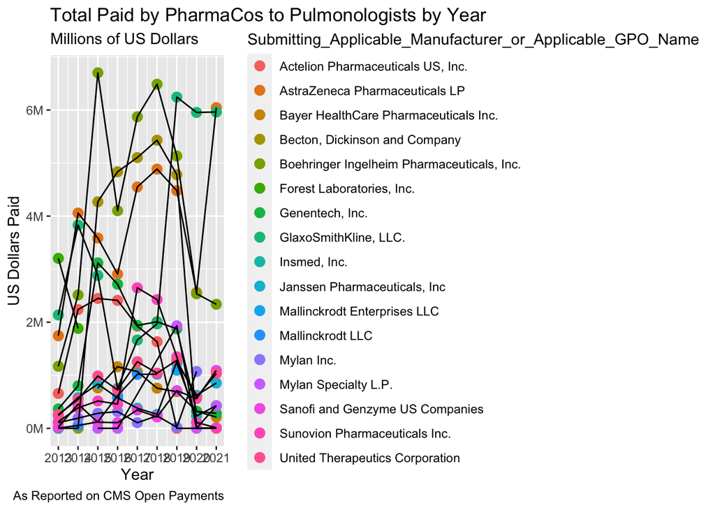

## Further Analysis

- how many payments to docs per year by company
- payments by doc within a company - histogram - KOL strategy?

## Now Top Individual Recipients

Not counting Royalties

573 docs over 100K from 2013-2021 88 over 500K 23 over 1M

Table of Top 23

Open Payments, Big Pharma Spend on Pulmonary

by Doctor, 2013-2021

| First Name | Last Name | Dollars |
| --- | --- | --- |
| DOUGLAS | HOGARTH | 2,703,276.08 |
| SAMUEL | LOUIE | 2,231,477.50 |
| ANTONIO | ANZUETO | 1,960,987.47 |
| STEVEN | NATHAN | 1,884,994.25 |
| FRANCK | RAHAGHI | 1,867,597.95 |
| MARK | RUMBAK | 1,841,367.41 |
| GARY | FERGUSON | 1,795,033.61 |
| RONALD | BALKISSOON | 1,694,394.44 |
| DONALD | TASHKIN | 1,677,531.64 |
| REVATI | SHREENIWAS | 1,563,765.92 |
| DENNIS | DOHERTY | 1,442,082.77 |
| LAWRENCE | MCDERMOTT | 1,386,031.92 |
| DAVID | WILSON | 1,359,554.70 |
| LONNY | YARMUS | 1,327,150.38 |
| OMAR | MINAI | 1,309,912.54 |
| GEOFFREY | CHUPP | 1,307,775.80 |
| DAVID | MARES | 1,266,099.34 |
| ABHIJIT | RAVAL | 1,115,552.99 |
| JAVIER | PEREZ-FERNANDEZ | 1,089,309.08 |
| SEPTIMIU | MURGU | 1,077,445.22 |
| JOHN | MCCONNELL | 1,053,157.92 |
| JEFFREY | MISKOFF | 1,049,462.58 |
| MARIO | CASTRO | 1,027,138.78 |

Of note, only one female

High number (over-representative) raised, educated outside the US on the top list?

What is the denominator - how many pulmonary docs in US, how many foreign-born, foreign-educated?

Academic vs non-academic?

Religious hospitals vs secular?

## Top by Royalty or License

Anyone over 10K

Total of only 7 docs in 2013-2021. Lots for Lyntek Corp based on sepsis patents. http://lyntekmedical.com

Table

Open Payments, Big Pharma Spend on Pulmonary

Royalties by Doctor, 2013-2021, Total > $10K

| First Name | Last Name | Dollars |
| --- | --- | --- |
| LAWRENCE | LYNN | 24,915,127.00 |
| KO-PEN | WANG | 608,358.39 |
| GERALD | SMALDONE | 323,622.54 |
| DONALD | MAHLER | 142,500.00 |
| MICHAEL | ZGODA | 32,617.99 |
| JAMES | KRINSLEY | 24,999.99 |
| IRVING | MIZUS | 19,795.27 |

## Top Recipients from Top Companies

Which of the Top 17 Companies are spending the most on specific docs?

```
## 'Submitting_Applicable_Manufacturer_or_Applicable_GPO_Name',
## 'Physician_First_Name'. You can override using the `.groups`
## argument.
```

Open Payments, Big Pharma Spend on Pulmonary

Royalties by Doctor, 2013-2021, Total > $100K

| Last Name | Dollars |
| --- | --- |
| Actelion Pharmaceuticals US, Inc. - OMAR |  |
| MINAI | 499,975.97 |
| Actelion Pharmaceuticals US, Inc. - LEWIS |  |
| RUBIN | 497,562.10 |
| Actelion Pharmaceuticals US, Inc. - FERNANDO |  |
| TORRES | 461,964.41 |
| Actelion Pharmaceuticals US, Inc. - JOHN |  |
| MCCONNELL | 431,813.85 |
| Actelion Pharmaceuticals US, Inc. - ABHIJIT |  |
| RAVAL | 310,347.89 |
| Actelion Pharmaceuticals US, Inc. - HARRISON |  |
| FARBER | 273,765.80 |
| Actelion Pharmaceuticals US, Inc. - HYONG |  |
| KIM | 270,422.65 |
| Actelion Pharmaceuticals US, Inc. - MARK |  |
| RUMBAK | 216,286.60 |
| Actelion Pharmaceuticals US, Inc. - CHARLES |  |
| IVESTER | 187,146.31 |
| Actelion Pharmaceuticals US, Inc. - CHAD |  |
| MILLER | 171,230.72 |
| Actelion Pharmaceuticals US, Inc. - ADAANI |  |
| FROST | 156,209.65 |
| Actelion Pharmaceuticals US, Inc. - WASSIM |  |
| FARES | 152,970.39 |
| Actelion Pharmaceuticals US, Inc. - SONJA |  |
| BARTOLOME | 152,704.80 |
| Actelion Pharmaceuticals US, Inc. - DAVID |  |
| ROSS | 150,307.49 |
| Actelion Pharmaceuticals US, Inc. - DEMOSTHENES |  |
| PAPAMATHEAKIS | 149,373.80 |

[output cut: 642 more lines]

## Top Recipients by Drug from Top Companies

Which of the Top 17 Companies are spending the most on specific docs for Specific Drugs?

Aka, Who is Team Symbicort vs Team Trelegy?

```
## 'Submitting_Applicable_Manufacturer_or_Applicable_GPO_Name',
## 'Name_of_Drug_or_Biological_or_Device_or_Medical_Supply_1',
## 'Physician_First_Name'. You can override using the `.groups`
## argument.
```

Open Payments, Big Pharma Spend on Pulmonary

[output not shown]

[output cut: 1241 more lines]

## Who are the Hungry Hippos - most Food and Beverage $$

```
## You can override using the `.groups` argument.
```

Who Are The Hungriest Hippos in Pulmonary

Food and Beverage by Doctor, 2013-2021, Total > $20K, N = 186

| Name | Dollars |
| --- | --- |
| FRANCK RAHAGHI | 82,086.20 |
| DOUGLAS HOGARTH | 70,307.65 |
| SAMUEL LOUIE | 65,270.60 |
| MARK RUMBAK | 61,077.76 |
| JEFFREY WOLF | 54,331.74 |
| JEFFREY MISKOFF | 48,617.80 |
| CARLOS SANTOS | 47,389.58 |
| JOHN MCCONNELL | 45,517.18 |
| JAVIER PEREZ-FERNANDEZ | 45,419.61 |
| MICHAEL PRITCHETT | 43,670.28 |
| NEIL MUSHLIN | 41,952.57 |
| SHYAMSUNDER SUBRAMANIAN | 40,921.71 |
| SHERIF EL-BAYADI | 40,628.73 |
| GARY FERGUSON | 40,539.79 |
| MOUHAMMED RIHAWI | 38,933.68 |
| LONNY YARMUS | 38,885.68 |
| THOMAS POLLARD | 36,965.36 |
| ALVARO ARANDA | 36,425.07 |
| DONALD TASHKIN | 36,222.78 |
| BORIS SAGALOVICH | 36,136.94 |
| JACK MANN | 35,991.64 |
| STEVEN NATHAN | 35,433.74 |
| KEITH HARRIS | 35,152.82 |
| DAVID MILLER | 34,883.05 |
| DAVID MARES | 34,712.78 |
| STEVEN GELLER | 34,660.79 |
| MICHAEL MANDEL | 34,452.64 |
| CARLOS SILVA | 33,365.59 |
| ROBERT SCHREIBER | 33,323.12 |
| TONY HODGES | 33,288.39 |

[output cut: 152 more lines]

## Who Never Eats At Home - most Food and Beverage Payments

Which Pulmonary Docs Never Eat At Home

Food and Beverage by Doctor, 2013-2021, N = 234 More than 100 meals out per year - only 208 weeknights per year available to eat dinner out over 9 years - 9*208

| Name | Meals |
| --- | --- |
| NEIL MUSHLIN | 2523 |
| STEVEN GELLER | 2019 |
| CARLOS SANTOS | 1956 |
| SANOBER KABLE | 1945 |
| CARLOS SILVA | 1932 |
| TIMOTHY KILLEEN | 1911 |
| KENNETH LLOYD | 1826 |
| HIMANSHU DESAI | 1825 |
| FRANCK RAHAGHI | 1801 |
| NELSON GREENE | 1705 |
| MOHAMMAD SHEATT | 1594 |
| THOMAS POLLARD | 1588 |
| TIMOTHY LUCAS | 1581 |
| JEFFREY WOLF | 1576 |
| JAMES WITTEN | 1574 |
| JOHN RODGERS | 1574 |
| MICHAEL HENIFF | 1563 |
| DOUGLAS DORSEY | 1494 |
| MICHAEL WERT | 1491 |
| GEORGE ZLUPKO | 1463 |
| TAPAS BANDYOPADHYAY | 1458 |
| ADRIAN DIVITTORIO | 1440 |
| RAMIT SHARMA | 1439 |
| SHERIF EL-BAYADI | 1414 |
| MAGDY METTIAS | 1407 |
| DOUGLAS HOGARTH | 1405 |
| LUIS SANCHEZ | 1401 |
| JAMES LOGOTHETIS | 1386 |
| DON WYNN | 1384 |
| JAMES LAMPASSO | 1383 |

[output cut: 200 more lines]